# Selenium Demo

A demo to the minimum steps for scrapping a site that requires interaction with javascript. Here I did not implement any advanced stuffs like random timeout. If you are interested, you can visit the [documentation page of selenium](https://www.selenium.dev/documentation/webdriver/).

## 0. Install the correct version of webdriver (Using Chrome for demo)

The first step of using Selenium is to make sure you install the same version of webdriver as your browser. Here I am using Google Chrome for demonstration. To check the version of your Chrome browser, navigate to `chrome://settings/help` in the browser.

[figure not shown]

Then go to the chrome release page https://googlechromelabs.github.io/chrome-for-testing/ to find the chrome driver that has the same version number (the first 3 digits) as your browser and match the spec of your computer. For example, I am running this code on a windows 64bit computer. Copy the link, download and decompress the file, and then save the `chromedriver.exe` file to your desired location.

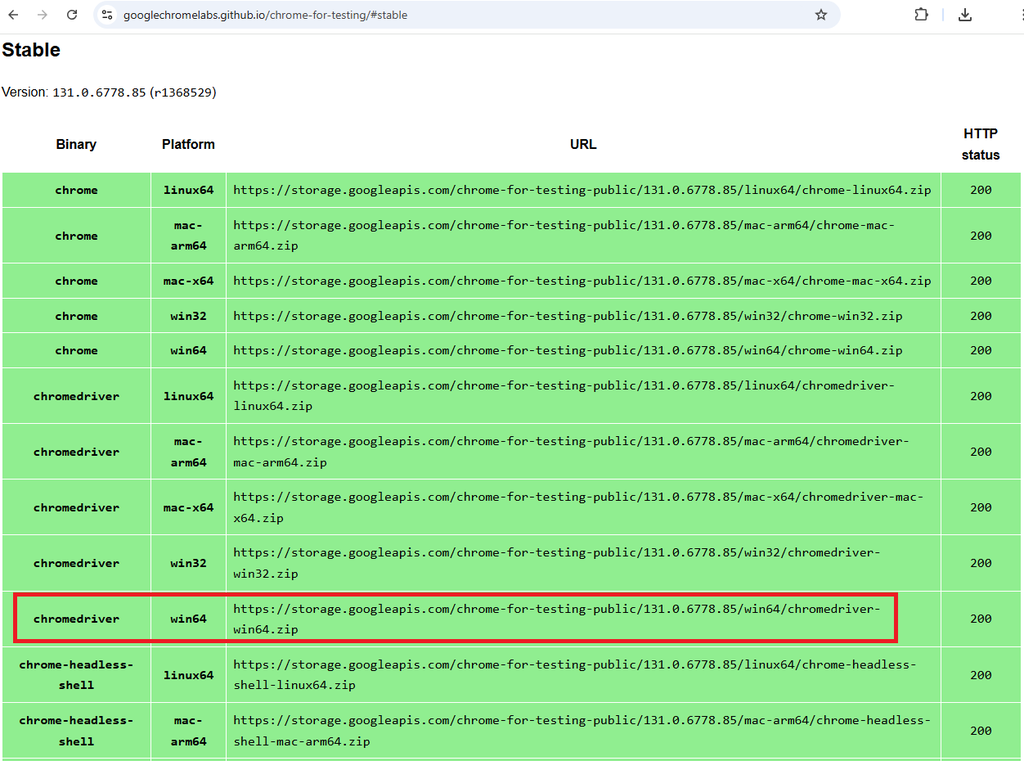

## 1. Launch a headless browser

Setting up with the following code, you can open a new Chrome browser and control the scrapping routine with Python. Scrapping with an open browser allows us to check the steps of our script. In the real routine, we always suppress the browser popping out by adding the `headless` option, so that the computer does not have to render what it is running and can save memories.

```python
from selenium import webdriver
from selenium.webdriver.chrome.service import Service
from selenium.webdriver.chrome.options import Options
from selenium.webdriver.common.by import By
```

```python
service = Service(r'webdriver\chromedriver.exe')
options = Options()
#options.add_argument("headless")              # headless is the option to whether to have a browser popping out
driver = webdriver.Chrome(service=service, options=options)
```

## 2. Navigate to a webpage

Just like in `requests`, we can use the `.get()` method to go to the page we want to scrap.

```python
driver.get("https://search.kmb.hk/kmbwebsite/")
```

## 3. Locate the HTML element

Unlike us reading a webpage by our eyes through the screen, what the webdriver understand the webpage is by the page's DOM tree. Therefore to interact with the page, we need to first tell the webdriver which HTML elements we want to interact with. There are many methods to specify the HTML elements, with most commonly the `ID` and `XPATH`.

In google chrome, we can press `F12` on the keyboard to open the developer panel and use its element selecting tool to locate the HTML element. Clicking on the page will highlight the HTML code of that element.

[figure not shown]

## 4. Interact with the page

Afterwards, we can interact with the browser just like using a mouse clicking on the page, or using a keyboard typing specific inputs. For example,

1. Click on route serach button

```python
route_button = driver.find_element(By.ID, 'imgRouteSearchIcon')
route_button.click()
```

2. Type the bus line number into the input field

```python
line_no = driver.find_element(By.ID, 'txtRoute')
line_no.clear()
line_no.send_keys('91')
```

3. Click the search button

```python
search_button = driver.find_element(By.ID, 'routeSearchButton')
search_button.click()
```

## 5. Scrapping with for loop

Here demonstrate a routine of scrapping the estimate arrival time (ETA) at all the station along the bus route. To read these information, we interact with the following steps:

- Click on each station's name.
- Extract the information in the panel appearing on the map.

We can script with selenium to perform the same actions. Note that selenium can only select element that are visible in the viewport, so you need to excecute javascript to scroll the bottom stations into view.

```python
# it takes some time before the website returning the search result
# so we need to tell the driver to wait a bit until the table elements show up
driver.implicitly_wait(5)

stop_list = []

# first stop and last stop have a different xpath selector
first_stop = driver.find_element(By.XPATH, '//td[contains(@class, "routeStopStartBulletTextTD")]')
last_stop = driver.find_element(By.XPATH, '//td[contains(@class, "routeStopEndBulletTextTD")]')

stops = driver.find_elements(By.XPATH, '//td[contains(@class, "imgHover") and contains(@class, "stopTd")]')
stops = [first_stop]+stops+[last_stop]

for stop in stops:

    # this is the javascript to scroll into view
    driver.execute_script("arguments[0].scrollIntoView();", stop)
    driver.implicitly_wait(2) # add a waiting time in between clicking
    stop.click()

    time_table = driver.find_elements(By.XPATH, '//div[@class="contentPane"]/table/tbody/tr[5]/td/table/tbody/tr[position()>1]')
    stop_list.append([stop.text]+[time.text for time in time_table])
```

```python
print(stop_list)
```

```
[['清水灣總站', '', '', ''], ['清水灣第一灘', '', '', ''], ['大環頭路', '15 分鐘 預定班次', '35 分鐘 預定班次', '55 分鐘 預定班次'], ['相思灣', '暫時無法提供'], ['兩塊田', '17 分鐘 預定班次', '37 分鐘 預定班次', '57 分鐘 預定班次'], ['下洋', '18 分鐘 預定班次', '38 分鐘 預定班次', '57 分鐘 預定班次'], ['上洋', '19 分鐘 預定班次', '39 分鐘 預定班次', '58 分鐘 預定班次'], ['檳榔灣', '即將到達', '20 分鐘 預定班次', …
```

## 6. Use pandas to organize

Then you can do the analysis by pandas or after exporting to excel as you like.

```python
import pandas as pd
```

```python
for eta in stop_list:
    while len(eta)<4:    # sometimes the ETA data cannot be provided
        eta.append("")

df = pd.DataFrame(stop_list, columns=['name', 'bus1', 'bus2', 'bus3'])

df
```

|  | name | bus1 | bus2 | bus3 |
| --- | --- | --- | --- | --- |
| 0 | 清水灣總站 |  |  |  |
| 1 | 清水灣第一灘 |  |  |  |
| 2 | 大環頭路 | 15 分鐘 預定班次 | 35 分鐘 預定班次 | 55 分鐘 預定班次 |
| 3 | 相思灣 | 暫時無法提供 |  |  |
| 4 | 兩塊田 | 17 分鐘 預定班次 | 37 分鐘 預定班次 | 57 分鐘 預定班次 |
| 5 | 下洋 | 18 分鐘 預定班次 | 38 分鐘 預定班次 | 57 分鐘 預定班次 |
| 6 | 上洋 | 19 分鐘 預定班次 | 39 分鐘 預定班次 | 58 分鐘 預定班次 |
| 7 | 檳榔灣 | 即將到達 | 20 分鐘 預定班次 | 40 分鐘 預定班次 |
| 8 | 五塊田 | 即將到達 | 21 分鐘 預定班次 | 41 分鐘 預定班次 |
| 9 | 孟公屋 | 1 分鐘 | 22 分鐘 預定班次 | 42 分鐘 預定班次 |
| 10 | 碧沙路 | 2 分鐘 | 22 分鐘 預定班次 | 42 分鐘 預定班次 |
| 11 | 銀線灣廣場 | 3 分鐘 | 23 分鐘 預定班次 | 43 分鐘 預定班次 |
| 12 | 坑口道 | 4 分鐘 | 24 分鐘 預定班次 | 44 分鐘 預定班次 |
| 13 | 影業路 | 5 分鐘 | 25 分鐘 預定班次 | 45 分鐘 預定班次 |
| 14 | 銀影路 | 7 分鐘 | 27 分鐘 預定班次 | 47 分鐘 預定班次 |
| 15 | 香港科技大學(南) | 9 分鐘 | 29 分鐘 預定班次 | 49 分鐘 預定班次 |
| 16 | 大埔仔 | 11 分鐘 | 31 分鐘 預定班次 | 51 分鐘 預定班次 |
| 17 | 大埔仔坳 | 即將到達 | 16 分鐘 | 36 分鐘 預定班次 |
| 18 | 打鼓嶺新村 | 1 分鐘 | 17 分鐘 | 37 分鐘 預定班次 |
| 19 | 壁屋 | 3 分鐘 | 19 分鐘 | 39 分鐘 預定班次 |
| 20 | 白石窩 | 4 分鐘 | 21 分鐘 | 41 分鐘 預定班次 |
| 21 | 井欄樹 | 6 分鐘 | 22 分鐘 | 42 分鐘 預定班次 |
| 22 | 龍窩村 | 7 分鐘 | 23 分鐘 | 43 分鐘 預定班次 |
| 23 | 安達臣道 | 8 分鐘 | 24 分鐘 | 44 分鐘 預定班次 |
| 24 | 德望學校 | 8 分鐘 | 24 分鐘 | 44 分鐘 預定班次 |
| 25 | 彩雲邨 | 11 分鐘 | 27 分鐘 |  |
| 26 | 牛池灣轉車站 - 彩虹站 (K2月台) | 1 分鐘 | 13 分鐘 | 30 分鐘 |
| 27 | 牛池灣轉車站 - 紅萼樓 (H3月台) | 5 分鐘 | 17 分鐘 | 33 分鐘 |
| 28 | 彩虹轉車站 - 錦雲樓 (P2月台) | 9 分鐘 | 21 分鐘 | 38 分鐘 |
| 29 | 志蓮淨苑 | 10 分鐘 | 22 分鐘 | 38 分鐘 |
| 30 | 鑽石山站巴士總站 | 13 分鐘 | 25 分鐘 | 41 分鐘 |

## 7. Kill the browser

There is no reason to keep the browser running each time we finish running a script. So remember to kill it so save resources.

```python
driver.quit()
```